# 7 Multicollinearity

## 背景描述

资产评估：科学的大众评估是将线性回归方法应用于资产评估问题的一种技术。科学大规模评估的目的是根据选定的建筑物的物理特性和对建筑物支付的税费(地方、学校、县)预测房屋的销售价格。这些数据最初是由Narula和Wellington(1977)提出的，我们观察 24 个观测值。

由此我们构造了 24 个观测的 9 个变量，具体请见下表：

## 数据描述

| 变量名 | 变量含义 | 变量类型 | 变量取值范围 |
| --- | --- | --- | --- |
| （自变量）X1 | 数千美元税收(当地，县，学校) | continuous variable | $\mathbb{R}^+$ |
| （自变量）X2 | 浴室的数量 | continuous variable | $\mathbb{R}^+$ |
| （自变量）X3 | 批量(千平方英尺) | continuous variable | $\mathbb{R}^+$ |
| （自变量）X4 | 居住面积(千平方英尺) | continuous variable | $\mathbb{R}^+$ |
| （自变量）X5 | 车库档位数量 | continuous variable | $\mathbb{R}^+$ |
| （自变量）X6 | 房间的数量 | continuous variable | $\mathbb{R}^+$ |
| （自变量）X7 | 卧室的数量 | continuous variable | $\mathbb{R}^+$ |
| （自变量）X8 | 住宅年龄(年) | continuous variable | $\mathbb{R}^+$ |
| （自变量）X9 | 壁炉的数量 | continuous variable | $\mathbb{R}^+$ |
| （因变量）Y | 数千美元房子的售价 | continuous variable | $\mathbb{R}^+$ |

## 问题

注：这里使用 \alpha=0.05 的显著性水平

1. 判断变量间是否具有多重共线性.
2. 如果存在多重共线性，如何消除多重共线性/选择变量.

## 解决方案

**Q1：**

```python
# Import standard packages
import numpy as np
import pandas as pd
import scipy.stats as stats
import matplotlib.pyplot as plt
import seaborn as sns
import math
```

```python
# Import additional packages
from itertools import combinations
import statsmodels.api as sm
from statsmodels.stats.outliers_influence import variance_inflation_factor

alpha = 0.05
p = 9
n = 24

x = pd.read_csv('data/Project7.csv')
x.insert(0, 'intercept', np.ones(len(x)))
data = x.values * 1
df = pd.DataFrame(data)
print(df.head())

X = data[:,0:p+1]
Y = data[:,-1]
```

```
     0      1    2      3      4    5    6    7     8    9    10
0  1.0  4.918  1.0  3.472  0.998  1.0  7.0  4.0  42.0  0.0  25.9
1  1.0  5.021  1.0  3.531  1.500  2.0  7.0  4.0  62.0  0.0  29.5
2  1.0  4.543  1.0  2.275  1.175  1.0  6.0  3.0  40.0  0.0  27.9
3  1.0  4.557  1.0  4.050  1.232  1.0  6.0  3.0  54.0  0.0  25.9
4  1.0  5.060  1.0  4.455  1.121  1.0  6.0  3.0  42.0  0.0  29.9
```

**数据预处理：**

```python
# 对自变量 X 进行标准化
# 自变量 X 的均值
X_mean = []
for i in range(p):
    X_mean.append(np.mean(X[:, i+1]))
```

```python
# 自变量 X 的标准差
X_L = []
for i in range(p):
    X_L.append(sum((X[:, i+1] - X_mean[i]) ** 2))

# 对自变量 X 标准化(截距项不用标准化)
X_std = X * 1.0
X_std[:,1:p+1] = (X[:,1:p+1] - X_mean) / np.sqrt(X_L)
```

用原始数据回归

```python
# Do the multiple linear regression
# OLS（endog,exog=None,missing='none',hasconst=None) (endog:因变量，exog=自变量）
model = sm.OLS(Y, X).fit()
Y_hat = model.fittedvalues
model.summary()
```

OLS Regression Results

| Dep. Variable: | y | R-squared: | 0.851 |
| --- | --- | --- | --- |
| Model: | OLS | Adj. R-squared: | 0.756 |
| Method: | Least Squares | F-statistic: | 8.898 |
| Date: | Fri, 16 Apr 2021 | Prob (F-statistic): | 0.000202 |
| Time: | 01:34:28 | Log-Likelihood: | -53.735 |
| No. Observations: | 24 | AIC: | 127.5 |
| Df Residuals: | 14 | BIC: | 139.3 |
| Df Model: | 9 |  |  |
| Covariance Type: | nonrobust |  |  |

|  | coef | std err | t | P>\|t\| | [0.025 | 0.975] |
| --- | --- | --- | --- | --- | --- | --- |
| const | 15.3104 | 5.961 | 2.568 | 0.022 | 2.526 | 28.095 |
| x1 | 1.9541 | 1.038 | 1.882 | 0.081 | -0.273 | 4.181 |
| x2 | 6.8455 | 4.335 | 1.579 | 0.137 | -2.453 | 16.144 |
| x3 | 0.1376 | 0.494 | 0.278 | 0.785 | -0.923 | 1.198 |
| x4 | 2.7814 | 4.395 | 0.633 | 0.537 | -6.645 | 12.207 |
| x5 | 2.0508 | 1.385 | 1.481 | 0.161 | -0.919 | 5.020 |
| x6 | -0.5559 | 2.398 | -0.232 | 0.820 | -5.699 | 4.587 |
| x7 | -1.2452 | 3.423 | -0.364 | 0.721 | -8.587 | 6.096 |
| x8 | -0.0380 | 0.067 | -0.565 | 0.581 | -0.182 | 0.106 |
| x9 | 1.7045 | 1.953 | 0.873 | 0.398 | -2.485 | 5.894 |

| Omnibus: | 1.516 | Durbin-Watson: | 1.857 |
| --- | --- | --- | --- |
| Prob(Omnibus): | 0.469 | Jarque-Bera (JB): | 1.100 |
| Skew: | 0.262 | Prob(JB): | 0.577 |
| Kurtosis: | 2.091 | Cond. No. | 470. |

Warnings:  
[1] Standard Errors assume that the covariance matrix of the errors is correctly specified.

用自变量经标准化后的数据回归

```python
# Do the multiple linear regression
# OLS（endog,exog=None,missing='none',hasconst=None) (endog:因变量，exog=自变量）
model_std = sm.OLS(Y, X_std).fit()
Y_std_hat = model_std.fittedvalues
model_std.summary()
```

OLS Regression Results

| Dep. Variable: | y | R-squared: | 0.851 |
| --- | --- | --- | --- |
| Model: | OLS | Adj. R-squared: | 0.756 |
| Method: | Least Squares | F-statistic: | 8.898 |
| Date: | Fri, 16 Apr 2021 | Prob (F-statistic): | 0.000202 |
| Time: | 01:34:31 | Log-Likelihood: | -53.735 |
| No. Observations: | 24 | AIC: | 127.5 |
| Df Residuals: | 14 | BIC: | 139.3 |
| Df Model: | 9 |  |  |
| Covariance Type: | nonrobust |  |  |

|  | coef | std err | t | P>\|t\| | [0.025 | 0.975] |
| --- | --- | --- | --- | --- | --- | --- |
| const | 34.6292 | 0.607 | 57.065 | 0.000 | 33.328 | 35.931 |
| x1 | 14.8258 | 7.878 | 1.882 | 0.081 | -2.070 | 31.722 |
| x2 | 7.9045 | 5.006 | 1.579 | 0.137 | -2.832 | 18.641 |
| x3 | 1.2966 | 4.658 | 0.278 | 0.785 | -8.694 | 11.287 |
| x4 | 3.6852 | 5.823 | 0.633 | 0.537 | -8.803 | 16.174 |
| x5 | 5.9459 | 4.014 | 1.481 | 0.161 | -2.664 | 14.556 |
| x6 | -2.3585 | 10.173 | -0.232 | 0.820 | -24.178 | 19.461 |
| x7 | -3.3719 | 9.269 | -0.364 | 0.721 | -23.253 | 16.509 |
| x8 | -2.5590 | 4.529 | -0.565 | 0.581 | -12.273 | 7.155 |
| x9 | 3.6157 | 4.143 | 0.873 | 0.398 | -5.271 | 12.502 |

| Omnibus: | 1.516 | Durbin-Watson: | 1.857 |
| --- | --- | --- | --- |
| Prob(Omnibus): | 0.469 | Jarque-Bera (JB): | 1.100 |
| Skew: | 0.262 | Prob(JB): | 0.577 |
| Kurtosis: | 2.091 | Cond. No. | 23.7 |

Warnings:  
[1] Standard Errors assume that the covariance matrix of the errors is correctly specified.

**预判变量间是否存在多重共线性**

**方法1： 直观判定法**

```python
# x为原始数据
x.drop('intercept',axis = 1,inplace = True)
r = pd.DataFrame(x).corr()
r
```

|  | X1 | X2 | X3 | X4 | X5 | X6 | X7 | X8 | X9 | Y |
| --- | --- | --- | --- | --- | --- | --- | --- | --- | --- | --- |
| X1 | 1.000000 | 0.651267 | 0.689212 | 0.734274 | 0.458556 | 0.640616 | 3.671126e-01 | -0.437101 | 1.466825e-01 | 0.873912 |
| X2 | 0.651267 | 1.000000 | 0.412956 | 0.728592 | 0.224022 | 0.510310 | 4.264014e-01 | -0.100748 | 2.041241e-01 | 0.709777 |
| X3 | 0.689212 | 0.412956 | 1.000000 | 0.571552 | 0.204664 | 0.392124 | 1.516093e-01 | -0.352751 | 3.059946e-01 | 0.647636 |
| X4 | 0.734274 | 0.728592 | 0.571552 | 1.000000 | 0.358884 | 0.678861 | 5.743353e-01 | -0.139087 | 1.065612e-01 | 0.707766 |
| X5 | 0.458556 | 0.224022 | 0.204664 | 0.358884 | 1.000000 | 0.589387 | 5.412988e-01 | -0.020169 | 1.016185e-01 | 0.461468 |
| X6 | 0.640616 | 0.510310 | 0.392124 | 0.678861 | 0.589387 | 1.000000 | 8.703883e-01 | 0.124266 | 2.222222e-01 | 0.528444 |
| X7 | 0.367113 | 0.426401 | 0.151609 | 0.574335 | 0.541299 | 0.870388 | 1.000000e+00 | 0.313511 | -5.797951e-17 | 0.281520 |
| X8 | -0.437101 | -0.100748 | -0.352751 | -0.139087 | -0.020169 | 0.124266 | 3.135114e-01 | 1.000000 | 2.257796e-01 | -0.397403 |
| X9 | 0.146683 | 0.204124 | 0.305995 | 0.106561 | 0.101618 | 0.222222 | -5.797951e-17 | 0.225780 | 1.000000e+00 | 0.266878 |
| Y | 0.873912 | 0.709777 | 0.647636 | 0.707766 | 0.461468 | 0.528444 | 2.815200e-01 | -0.397403 | 2.668783e-01 | 1.000000 |

用自变量经标准化后的数据来求相关系数矩阵，得到结果与以上一样

```python
# 确实是一样的
X_std_b = np.delete(X_std,0,axis=1)
X_std_c = np.insert(X_std_b,9,x.iloc[:,-1],axis=1)
rs = pd.DataFrame(X_std_c).corr()
rs
```

|  | 0 | 1 | 2 | 3 | 4 | 5 | 6 | 7 | 8 | 9 |
| --- | --- | --- | --- | --- | --- | --- | --- | --- | --- | --- |
| 0 | 1.000000 | 0.651267 | 0.689212 | 0.734274 | 0.458556 | 0.640616 | 3.671126e-01 | -0.437101 | 1.466825e-01 | 0.873912 |
| 1 | 0.651267 | 1.000000 | 0.412956 | 0.728592 | 0.224022 | 0.510310 | 4.264014e-01 | -0.100748 | 2.041241e-01 | 0.709777 |
| 2 | 0.689212 | 0.412956 | 1.000000 | 0.571552 | 0.204664 | 0.392124 | 1.516093e-01 | -0.352751 | 3.059946e-01 | 0.647636 |
| 3 | 0.734274 | 0.728592 | 0.571552 | 1.000000 | 0.358884 | 0.678861 | 5.743353e-01 | -0.139087 | 1.065612e-01 | 0.707766 |
| 4 | 0.458556 | 0.224022 | 0.204664 | 0.358884 | 1.000000 | 0.589387 | 5.412988e-01 | -0.020169 | 1.016185e-01 | 0.461468 |
| 5 | 0.640616 | 0.510310 | 0.392124 | 0.678861 | 0.589387 | 1.000000 | 8.703883e-01 | 0.124266 | 2.222222e-01 | 0.528444 |
| 6 | 0.367113 | 0.426401 | 0.151609 | 0.574335 | 0.541299 | 0.870388 | 1.000000e+00 | 0.313511 | 5.551115e-17 | 0.281520 |
| 7 | -0.437101 | -0.100748 | -0.352751 | -0.139087 | -0.020169 | 0.124266 | 3.135114e-01 | 1.000000 | 2.257796e-01 | -0.397403 |
| 8 | 0.146683 | 0.204124 | 0.305995 | 0.106561 | 0.101618 | 0.222222 | 5.551115e-17 | 0.225780 | 1.000000e+00 | 0.266878 |
| 9 | 0.873912 | 0.709777 | 0.647636 | 0.707766 | 0.461468 | 0.528444 | 2.815200e-01 | -0.397403 | 2.668783e-01 | 1.000000 |

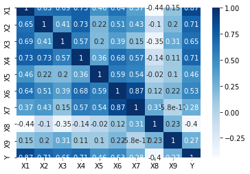

```python
sns.heatmap(r, cmap='Blues', annot=True)
```

1. 当与因变量之间的简单相关系数绝对值很大的自变量在回归方程中没有通过显著性检验时，可初步判断存在严重的多重共线性。

```python
r_xy = np.array(r.iloc[:p,p])
print('因变量和每个自变量之间的相关系数: \n', r_xy)
```

```
因变量和每个自变量之间的相关系数:
 [ 0.87391169  0.7097771   0.64763642  0.70776562  0.46146792  0.52844361
  0.28151997 -0.39740338  0.26687833]
```

```python
judge_xy = True
for i in range(p):
    if (abs(r_xy[i]) >= 0.5) & (model_std.pvalues[i+1] >= alpha):
        judge_xy = False
        print('自变量 %d 与因变量之间的简单相关系数为: %.4f, tPal: %.4f.' % (i+1, r_xy[i], model_std.pvalues[i+1]))

if judge_xy:
    print('\n自变量之间不存在多重共线性。')
else:
    print('\n自变量之间存在多重共线性。')
```

```
自变量 1 与因变量之间的简单相关系数为: 0.8739, tPal: 0.0808.
自变量 2 与因变量之间的简单相关系数为: 0.7098, tPal: 0.1367.
自变量 3 与因变量之间的简单相关系数为: 0.6476, tPal: 0.7848.
自变量 4 与因变量之间的简单相关系数为: 0.7078, tPal: 0.5370.
自变量 6 与因变量之间的简单相关系数为: 0.5284, tPal: 0.8200.

自变量之间存在多重共线性。
```

1. 在自变量的相关矩阵中，当自变量间的相关系数较大时会出现多重共线性的问题。

```python
judge_xx = True
for (i, j) in combinations(range(0, p), 2):
    if(r.iloc[i][j] >= 0.7):
        judge_xx = False
        print('变量(%d,%d)之间相关系数较大，为：%.4f'% (i+1, j+1, r.iloc[i][j]))

if judge_xx:
    print('\n自变量之间不存在多重共线性。')
else:
    print('\n自变量之间存在多重共线性。')
```

```
变量(1,4)之间相关系数较大，为：0.7343
变量(2,4)之间相关系数较大，为：0.7286
变量(6,7)之间相关系数较大，为：0.8704

自变量之间存在多重共线性。
```

**方法2：方差扩大因子法**

1. 计算自变量 $x_j$ 的方差扩大因子 $\mathsf{VIF_j}$，$j=1,\cdots,p$.

```python
# 法1：
c = np.dot(X_std.T, X_std)
C = np.linalg.inv(c)  # 求逆
C_list = []
for i in range(p):
    C_list.append(C[i + 1][i + 1])

# 法2：
vif = [variance_inflation_factor(X_std[:,1:p + 1], i) for i in range(p)]

print('C主对角线元素  方差扩大因子：')
for i in range(p):
    print('%d. %.4f        %.4f' % (i+1, C_list[i], vif[i]))
```

```
C主对角线元素  方差扩大因子：
1. 7.0219        7.0219
2. 2.8355        2.8355
3. 2.4549        2.4549
4. 3.8363        3.8363
5. 1.8234        1.8234
6. 11.7109        11.7109
7. 9.7218        9.7218
8. 2.3211        2.3211
9. 1.9424        1.9424
```

1. 通过 $\mathsf{VIF_j}$ 的大小判断自变量之间是否存在多重共线性.  
   如果VIF值大于10说明共线性很严重，这种情况需要处理，如果VIF值在5以下不需要处理，如果VIF介于5~10之间视情况而定。

```python
thres_vif = 5
for i in range(p):
    if vif[i] >= thres_vif:
        print('自变量 x%d 与其余自变量之间存在多重共线性，其中VIF值为：%.4f' % (i + 1, vif[i]))
```

```
自变量 x1 与其余自变量之间存在多重共线性，其中VIF值为：7.0219
自变量 x6 与其余自变量之间存在多重共线性，其中VIF值为：11.7109
自变量 x7 与其余自变量之间存在多重共线性，其中VIF值为：9.7218
```

**方法3：特征值判定法**

1. 计算自变量 $x_j$ 的条件数 $\kappa_j = \sqrt{\frac{\lambda_1}{\lambda_j}}$，$j=1,\cdots,p$.

```python
corr = np.corrcoef(X_std[:,1:p+1], rowvar = 0) # 相关系数矩阵 numpy中算相关系数矩阵没有除以自由度
# corr = np.dot(X_std[:,1:p+1].T,X_std[:,1:p+1]) # 这与以上是一样的
w, v = np.linalg.eig(corr) # 特征值 & 特征向量

kappa = []
for i in range(p):
    kappa.append(np.sqrt(max(w) / w[i]))
    print('特征值%d: %.4f, kappa%d: %.4f' %(i + 1, w[i], i + 1, kappa[i]))
```

```
特征值1: 4.2142, kappa1: 1.0000
特征值2: 1.7062, kappa2: 1.5716
特征值3: 1.1450, kappa3: 1.9185
特征值4: 0.7997, kappa4: 2.2955
特征值5: 0.4616, kappa5: 3.0216
特征值6: 0.0426, kappa6: 9.9503
特征值7: 0.2805, kappa7: 3.8760
特征值8: 0.1610, kappa8: 5.1156
特征值9: 0.1892, kappa9: 4.7198
```

1. 通过 $\kappa_p$ 的大小判断自变量之间是否存在多重共线性以及多重共线性的严重程度.  
   记 $\kappa=\lambda_{max}/ \lambda_{min}$，从实际应用的角度,一般若 $\kappa<100$，则认为多重共线性的程度很小，若是 $100<=\kappa<=1000$，则认为存在一般程度上的多重共线性，若是 $\kappa>1000$，则就认为存在严重的多重共线性.  
   $\kappa >= c_{\kappa}$时，自变量之间存在多重共线性，$c_{\kappa}$常见取值为10，100，1000.

```python
thres_kappa = 10
if np.max(kappa) >= thres_kappa:
    print('设计矩阵 X 存在多重共线性，其中kappa值为：%.4f' % np.max(kappa))
else:
    print('设计矩阵 X 不存在多重共线性，其中kappa值为：%.4f' % np.max(kappa))
```

```
设计矩阵 X 不存在多重共线性，其中kappa值为：9.9503
```

用特征值判别法没有判断出存在多重共线性，但是由于用前两个方法判断存在多重共线性，因此依然认为设计矩阵可疑，存在多重共线性

**Q2：**  
消除多重共线性：

1. 剔除不重要的解释变量
2. 增大样本量

**方法1：剔除不重要的解释变量**

（1）利用VIF删除导致高共线性的变量

```python
# 利用VIF删除导致高共线性的变量
# 截距项不应该进入变量选择 对于vif的范围....
col = list(range(X_std.shape[1]))
dropped = True
while dropped:
    dropped = False
    vif_drop = [variance_inflation_factor(X_std[:,col], i) for i in range(X_std[:,col].shape[1])]
    maxvif = max(vif_drop)
    maxix = vif_drop.index(maxvif)
    if maxvif > thres_vif:
        del col[maxix]
        dropped = True

    if dropped:
        print('剔除剩余变量中第 %d 列变量：' % maxix, '剩余变量：', col)

        # 利用 AIC、BIC 准则做变量选择的一个参考
        X_std_vif = X_std[:, col]
        model_vif = sm.OLS(Y, X_std_vif).fit()
        print('此时模型的AIC值为：%.4f'% model_vif.aic)
```

```
剔除剩余变量中第 6 列变量： 剩余变量： [0, 1, 2, 3, 4, 5, 7, 8, 9]
此时模型的AIC值为：125.5623
```

```python
# Do the multiple linear regression
X_std_vif = X_std[:, col]
model_vif = sm.OLS(Y, X_std_vif).fit()
model_vif.summary()
```

OLS Regression Results

| Dep. Variable: | y | R-squared: | 0.851 |
| --- | --- | --- | --- |
| Model: | OLS | Adj. R-squared: | 0.771 |
| Method: | Least Squares | F-statistic: | 10.68 |
| Date: | Fri, 16 Apr 2021 | Prob (F-statistic): | 5.94e-05 |
| Time: | 01:35:00 | Log-Likelihood: | -53.781 |
| No. Observations: | 24 | AIC: | 125.6 |
| Df Residuals: | 15 | BIC: | 136.2 |
| Df Model: | 8 |  |  |
| Covariance Type: | nonrobust |  |  |

|  | coef | std err | t | P>\|t\| | [0.025 | 0.975] |
| --- | --- | --- | --- | --- | --- | --- |
| const | 34.6292 | 0.587 | 58.955 | 0.000 | 33.377 | 35.881 |
| x1 | 13.7810 | 6.254 | 2.204 | 0.044 | 0.451 | 27.111 |
| x2 | 8.2433 | 4.634 | 1.779 | 0.096 | -1.635 | 18.121 |
| x3 | 1.3870 | 4.493 | 0.309 | 0.762 | -8.189 | 10.963 |
| x4 | 3.6215 | 5.630 | 0.643 | 0.530 | -8.378 | 15.621 |
| x5 | 5.9877 | 3.882 | 1.543 | 0.144 | -2.286 | 14.262 |
| x6 | -5.1787 | 4.857 | -1.066 | 0.303 | -15.531 | 5.174 |
| x7 | -2.5804 | 4.383 | -0.589 | 0.565 | -11.923 | 6.762 |
| x8 | 3.1554 | 3.520 | 0.896 | 0.384 | -4.347 | 10.658 |

| Omnibus: | 1.705 | Durbin-Watson: | 1.835 |
| --- | --- | --- | --- |
| Prob(Omnibus): | 0.426 | Jarque-Bera (JB): | 1.110 |
| Skew: | 0.217 | Prob(JB): | 0.574 |
| Kurtosis: | 2.039 | Cond. No. | 12.5 |

Warnings:  
[1] Standard Errors assume that the covariance matrix of the errors is correctly specified.

（2）后退法

```python
# 后退法
col0 = list(range(X_std.shape[1]))
col1 = col0 * 1
dropped1 = True
aic_model = sm.OLS(Y, X_std).fit().aic
while dropped1:
    X_std_aic = X_std[:, col1]
    model_aic = sm.OLS(Y, X_std_aic).fit().aic
    aic = []
    for i in range(len(col1)):
        col2 = col1 * 1
        del col2[i]
        aic.append(sm.OLS(Y, X_std[:, col2]).fit().aic)
    minaic = min(aic[1:len(aic)])  # 第一个是截距项，不进入变量选择
    minaic_rank = aic.index(minaic) # aic与col1是一一对应的
    # print(minaic_rank)
    minaic_ix = col1[minaic_rank]
    if minaic < model_aic:
        del col1[minaic_rank]
    else:
        dropped1 = False

    if dropped1:
        print('剔除剩余变量中第 %d 列变量：' % minaic_ix, '剩余变量：', col1)
        print('此时模型的AIC值为：%.4f'% minaic)
```

```
剔除剩余变量中第 6 列变量： 剩余变量： [0, 1, 2, 3, 4, 5, 7, 8, 9]
此时模型的AIC值为：125.5623
剔除剩余变量中第 3 列变量： 剩余变量： [0, 1, 2, 4, 5, 7, 8, 9]
此时模型的AIC值为：123.7143
剔除剩余变量中第 8 列变量： 剩余变量： [0, 1, 2, 4, 5, 7, 9]
此时模型的AIC值为：122.3525
剔除剩余变量中第 4 列变量： 剩余变量： [0, 1, 2, 5, 7, 9]
此时模型的AIC值为：121.2717
剔除剩余变量中第 9 列变量： 剩余变量： [0, 1, 2, 5, 7]
此时模型的AIC值为：120.3662
```

```python
# Do the multiple linear regression
X_std_aic = X_std[:, col1]
model_aic = sm.OLS(Y, X_std_aic).fit()
model_aic.summary()
```

OLS Regression Results

| Dep. Variable: | y | R-squared: | 0.832 |
| --- | --- | --- | --- |
| Model: | OLS | Adj. R-squared: | 0.797 |
| Method: | Least Squares | F-statistic: | 23.54 |
| Date: | Fri, 16 Apr 2021 | Prob (F-statistic): | 3.87e-07 |
| Time: | 01:35:04 | Log-Likelihood: | -55.183 |
| No. Observations: | 24 | AIC: | 120.4 |
| Df Residuals: | 19 | BIC: | 126.3 |
| Df Model: | 4 |  |  |
| Covariance Type: | nonrobust |  |  |

|  | coef | std err | t | P>\|t\| | [0.025 | 0.975] |
| --- | --- | --- | --- | --- | --- | --- |
| const | 34.6292 | 0.553 | 62.587 | 0.000 | 33.471 | 35.787 |
| x1 | 18.3019 | 3.964 | 4.617 | 0.000 | 10.005 | 26.599 |
| x2 | 9.7675 | 3.845 | 2.540 | 0.020 | 1.719 | 17.816 |
| x3 | 5.9737 | 3.547 | 1.684 | 0.109 | -1.451 | 13.398 |
| x4 | -5.9995 | 3.493 | -1.717 | 0.102 | -13.311 | 1.312 |

| Omnibus: | 2.014 | Durbin-Watson: | 2.005 |
| --- | --- | --- | --- |
| Prob(Omnibus): | 0.365 | Jarque-Bera (JB): | 1.096 |
| Skew: | -0.083 | Prob(JB): | 0.578 |
| Kurtosis: | 1.966 | Cond. No. | 9.94 |

Warnings:  
[1] Standard Errors assume that the covariance matrix of the errors is correctly specified.

**判定是否还存在多重共线性**

应该考虑将第3、4、6、8、9列变量删除，也就是使用后退法得到的结果,从上面的回归结果来看(Y, X_std_aic)，表现较好；如果只删除第6列变量，从上面的回归结果(Y,X_std_vif)来看，依然有较多变量很大程度不能通过t检验.

用两种方法来判断，使用后退法选择变量后，是否还存在多重共线性的问题

```python
vif_aic = [variance_inflation_factor(X_std_aic, i) for i in range(X_std_aic.shape[1])]
# 方差扩大因子法
print('方差扩大因子：')
for i in range(X_std_aic.shape[1] - 1):
    print('%.4f' % vif_aic[i + 1])

print('\n')
for i in range(X_std_aic.shape[1] - 1):
    if vif_aic[i + 1] >= thres_vif:
        print('自变量 x%d 与其余自变量之间存在多重共线性，其中VIF值为: %.4f' % (i + 1, vif_aic[i + 1]))
```

```
方差扩大因子：
2.1389
2.0124
1.7127
1.6611
```

```python
# 特征值判定法
corr_ = np.corrcoef(X_std_aic[:,1:p+1], rowvar = 0) # 相关系数矩阵
w_, v_ = np.linalg.eig(corr_) # 特征值 & 特征向量

kappa_ = []
for i in range(X_std_aic.shape[1] - 1):
    kappa_.append(np.sqrt(w_[0] / w_[i]))
    print('特征值%d: %.4f, kappa%d: %.4f' %(i + 1, w_[i], i + 1, kappa_[i]))

if max(kappa_) >= thres_kappa:
    print('\n设计矩阵 X 存在多重共线性，其中 kappa 值为: %.4f' % max(kappa_))
else:
    print('\n设计矩阵 X 不存在多重共线性，其中 kappa 值为: %.4f' % max(kappa_))
```

```
特征值1: 2.3389, kappa1: 1.0000
特征值2: 0.8724, kappa2: 1.6374
特征值3: 0.2427, kappa3: 3.1041
特征值4: 0.5460, kappa4: 2.0697

设计矩阵 X 不存在多重共线性，其中 kappa 值为: 3.1041
```

综上，剔除原始数据的第3、4、6、8、9个变量，可以一定程度上消除变量间的多重共线性

**方法2：增大样本量**  
这里不用增大样本量，由于增加变量的方法，只是在于采集数据时，如果样本量过小可能会产生多重共线性的问题，因此需要采集足够多的样本。在实际分析阶段，往往无法增加样本量。